# There's no business like predicting the financial details of show business

Rowan Copley (March 2016)

Lately I've been trying to predict how much money a film will make in the box office. I started playing around with the idea because I play the Hollywood Stock Exchange, trading fake Internet dollars for "stocks" in a film to try to predict how much it will sell in tickets. It's a fun way of keeping up with which movies are coming out and how good I think they'll be. And of course, as any real-life stock trader will tell you, having data models can really help you beat the market.

First I'll import all the scripts I've written, which can be found on [GitHub](https://github.com/dovinmu/hsx).

```python
import boxoffice_analyze as boa
import matplotlib
import random
%matplotlib inline
matplotlib.pylab.rcParams['figure.figsize'] = (10.0, 8.0)
```

I've scraped daily box office takes from [Box Office Mojo](http://www.boxofficemojo.com/) for most of the top 200-grossing films of 2015 (leaving out the ones without daily data, and adding in a few stragglers from years past).

```python
print("Number of films in database:", len(boa.findFilm('')))
print('Films beginning with "St":\n', ', '.join([film[0] for film in boa.findFilm('st')]))
```

```
Number of films in database: 184
Films beginning with "St":
 Steve Jobs, Star Wars: The Force Awakens, Straight Outta Compton
```

If you plot the amount a film grosses each day, you start to see a very predictable pattern.

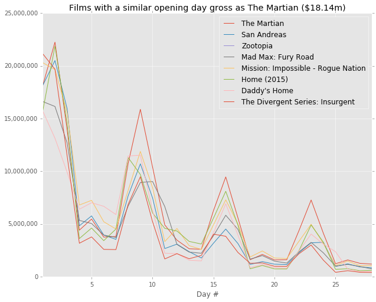

```python
boa.plotSimilarOpening('scott2016')
```

Which totally makes sense, because more people go to the movies on Thursday, Friday or Saturday than any other day of the week.

So my model basically exploits this fact, and just copies the first week over and over again, shrinking it down by some amount.

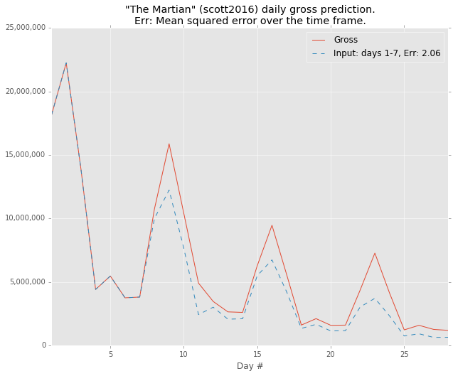

```python
boa.plotPredictionAndActual('scott2016')
```

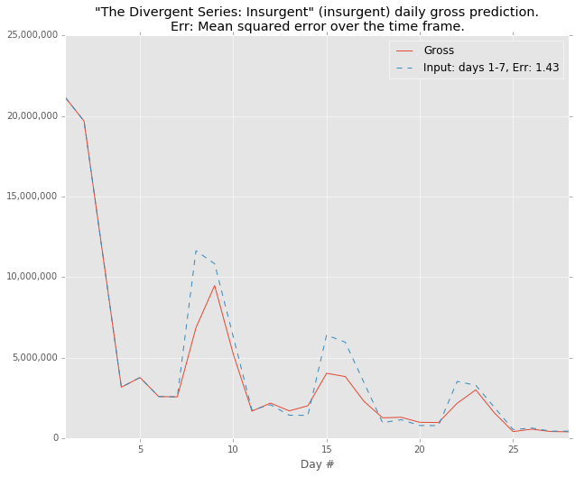

```python
boa.plotPredictionAndActual('insurgent')
```

If the model doesn't have the full first week, it tries to estimate the other days. The way it estimates the other days is it basically assumes that a weekend take will be five times a weekday's. Kind of hand-wavy, kinda based on the data, but it's good enough for our purposes. Here's what it looks like when we compare the full 7-day model with a model based just on the opening night, as well as a 3-day and 5-day.

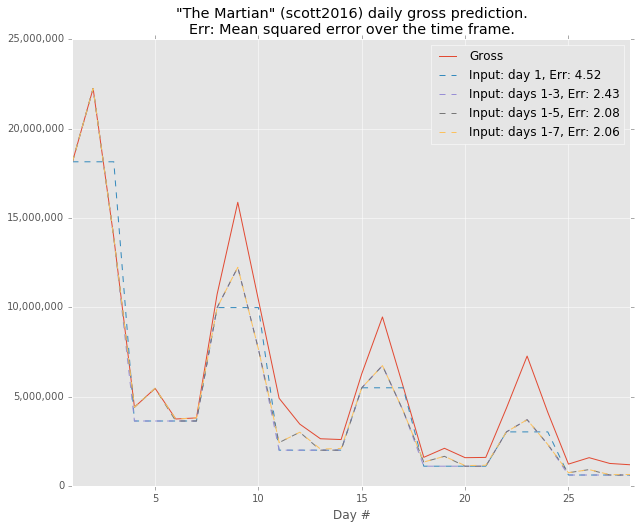

```python
boa.plotPredictionAndActual('scott2016', limit_day_input=[1,3,5,7])
```

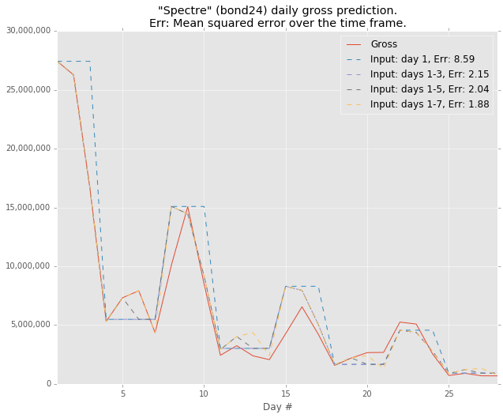

```python
boa.plotPredictionAndActual('bond24', limit_day_input=[1,3,5,7])
```

But what we're really trying to predict is the amount the film will make over the course of those first four weeks, or the cumulative total.

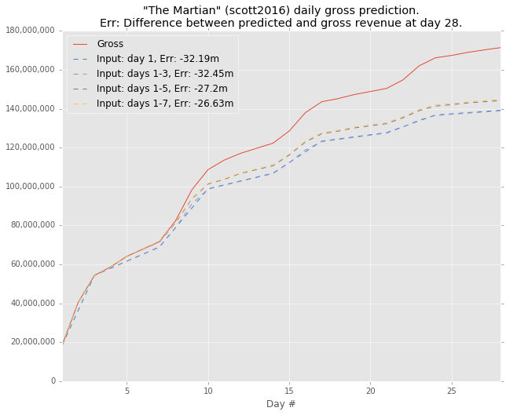

```python
boa.plotPredictionAndActual('scott2016', limit_day_input=[1,3,5,7], plot='cumsum')
```

The model keeps pace for the first few days, but then steadily falls behind. Meanwhile, it's all over the place for Star Wars, but manages to get a lot more accurate as more data is added.

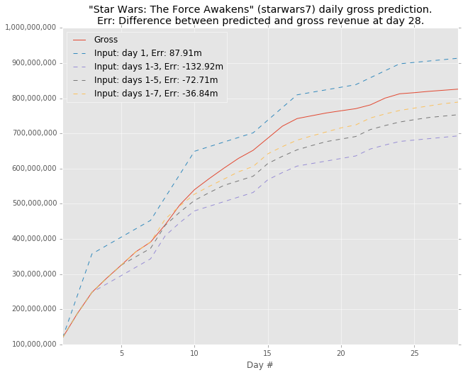

```python
boa.plotPredictionAndActual('starwars7', limit_day_input=[1,3,5,7], plot='cumsum')
```

Star Wars: The Force Awakens had an amazing (and record-shattering) opening day, which throws the model quite off-track, expecting the film to keep soaring and gross 900 million domestically in the first four weeks. But there are only so many people who go to the theater, and a huge number went on opening night. After the weekend, the model swings wildly in the other direction, predicting a domestic gross of only 700 million. Once we look at the whole week the model is doing pretty well, coming within 4% of predicting the eventual outcome.

# How good is the model really?

Let's look at how well the model's doing over all 184 films in the database. Here's a chart of how well the model did with the full week:

```python
df = boa.getCumsumOffsetMatrix(day=28)
matrix = df['cumError'].sort_values() * -1
```

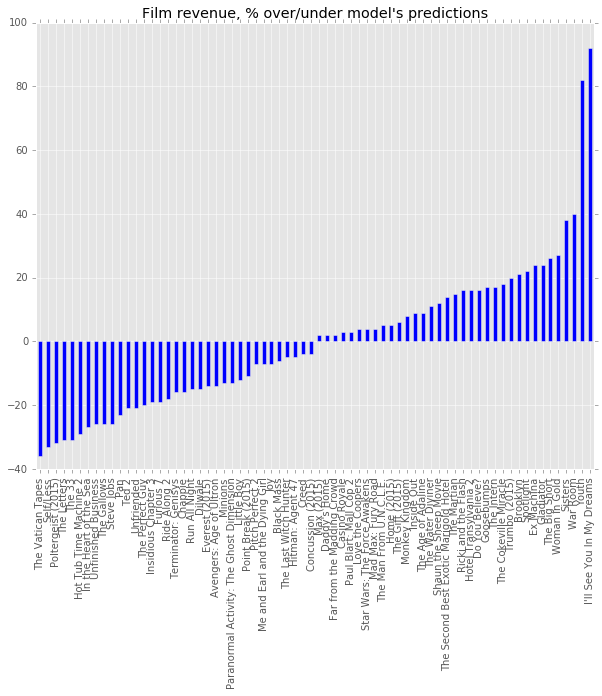

```python
matrix.sample(70).sort_values().plot(kind='bar', title="Film revenue, % over/under model's predictions")
```

This is plotting a bit less than half of the films for some semblance of readability, but it's pretty representative of all the films. The Martian is at 15% off the model, while Star Wars is in the middle at 4%.

Meanwhile, a few films are crazily off of their models. Here are the top and bottom 10% of films that most varied from their models:

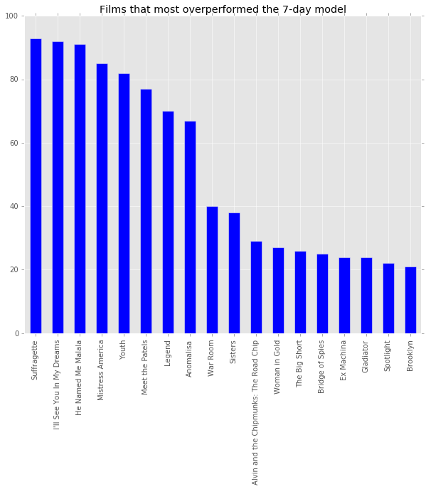

```python
matrix = df['cumError'].sort_values() * -1
matrix[:18].plot(kind='bar', title='Films that most overperformed the 7-day model')
```

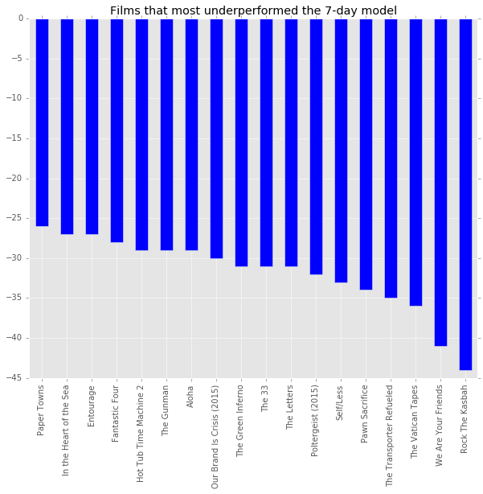

```python
matrix[-18:].plot(kind='bar', title='Films that most underperformed the 7-day model')
```

The films at the very extremes are the outliers, and we shouldn't really expect our model to predict them. Rock the Kasbah was by all accounts a terrible film, scoring 10% on Rotten Tomatoes, while Suffragette was a limited-release picture that didn't hit its stride until its third week in theaters.

Let's cut out the bottom and top 10% and then look at the extremes of the middle 80%.

```python
idx = int(len(df) / 10)
lower = min(matrix[idx:-idx])
upper = max(matrix[idx:-idx])
print('{0}% to {1}%'.format(lower, upper))
```

[output not shown]

```python
lower = lower/100
upper = upper/100
estimate_m = 100
print('Estimate: {0}m, 80% confidence: {1}m, {2}m'.format(estimate_m, estimate_m - estimate_m * abs(lower), estimate_m + estimate_m * upper))
```

[output not shown]

Not very amazing, though it's a start. It's a pretty simple model. It's not paying attention to reviews, it's barely even paying attention to whether even during the first week ticket sales are ballooning or crashing to the ground. But we can do better.

There is a correlation between the model's accuracy and the amount that the film ended up grossing. If we look only at films that grossed over 50 million, then a lot of the biggest extremes in over- or underperforming are left out.

```python
over50m = df[df['gross'] >= 50000000]
matrix = over50m['cumError'].sort_values()
idx = int(len(df) / 10)
lower = min(matrix[idx:-idx])
upper = max(matrix[idx:-idx])
print('{0}% to {1}%'.format(lower, upper))
lower = lower/100
upper = upper/100
estimate_m = 100
print('Estimate: {0}m, 80% confidence: {1}m, {2}m'.format(estimate_m, estimate_m - estimate_m * abs(lower), estimate_m + estimate_m * upper))
```

```
-5.0% to 11.0%
Estimate: 100m, 80% confidence: 95.0m, 111.0m
```

Now that's a bit better! Without even looking at anything but the first week of ticket sales we've got a reasonably confident model that doesn't give uselessly wide predictions.

With more data from years other than 2015 I'll feel more confident about computing the relationship between opening week gross and confidence interval for the eventual cumulative total of sales. Until then, thanks for reading!